# KNN.

Carlos Grande Nuñez, Veronica Gomez Gomez y Pablo Olmos Martinez

30/04/2020

# Libraries and fucntions

## Libraries

```r
# Basics
library(dplyr)
```

```r
library(ggplot2)
library(tidyr)
library(tictoc)

# Machine Learning
library(gmodels)
library(ROCit)
library(e1071)
```

## Functions

```r
split_data <- function(data, trn = .7, val = .2, tst = .1) {
  set.seed(737)
  spec = c(train = trn, validate = val, test = tst)
  # cutter
  g = sample(cut(seq(nrow(data)), nrow(data)*cumsum(c(0,spec)), labels = names(spec)))
  # spliter
  data <- split(data, g)
  return(data)
}
```

# 1 Loading Data

## 1.1 Reading the Data from the CSV

```r
file <- 'cluster.csv'
df_houses <-  read.csv(file)
head(df_houses)
```

```
##   X.2 X.1           X          Y         id       date   price bedrooms
## 1   1   1   3.7621642  22.445021 7129300520 10/13/2014  221900        3
## 2   2   2 -24.0359753   9.766915 6414100192  12/9/2014  538000        3
## 3   3   3   5.2170153   8.102678 5631500400  2/25/2015  180000        2
## 4   4   4   7.5887297  18.967730 2487200875  12/9/2014  604000        4
## 5   5   5   0.6661815   3.939548 1954400510  2/18/2015  510000        3
## 6   6   6  -2.6542516 -26.720289 7237550310  5/12/2014 1230000        4
##   bathrooms sqft_living sqft_lot floors waterfront view condition grade
## 1      1.00        1180     5650      1          0    0         3     7
## 2      2.25        2570     7242      2          0    0         3     7
## 3      1.00         770    10000      1          0    0         3     6
## 4      3.00        1960     5000      1          0    0         5     7
## 5      2.00        1680     8080      1          0    0         3     8
## 6      4.50        5420   101930      1          0    0         3    11
##   sqft_above sqft_basement yr_built yr_renovated zipcode     lat     long
## 1       1180             0     1955            0   98178 47.5112 -122.257
## 2       2170           400     1951         1991   98125 47.7210 -122.319
## 3        770             0     1933            0   98028 47.7379 -122.233
## 4       1050           910     1965            0   98136 47.5208 -122.393
## 5       1680             0     1987            0   98074 47.6168 -122.045
## 6       3890          1530     2001            0   98053 47.6561 -122.005
##   sqft_living15 sqft_lot15 cluster hclust Cluster_final
## 1          1340       5650       1      1           low
## 2          1690       7639       1      2           top
## 3          2720       8062       1      3           med
## 4          1360       5000       2      1           low
## 5          1800       7503       3      3           med
## 6          4760     101930       3      4           med
```

## 1.2 Adding a binary target

```r
quantile <- df_houses$price %>% quantile(0.75)
df_houses$target <- ifelse(df_houses$price>quantile, 'a', 'b')
df_houses <- df_houses %>% select(6, 8:25, 29)
table(df_houses$target)
```

```
##
##     a     b
##  5371 16226
```

```r
head(df_houses)
```

```
##         date bedrooms bathrooms sqft_living sqft_lot floors waterfront view
## 1 10/13/2014        3      1.00        1180     5650      1          0    0
## 2  12/9/2014        3      2.25        2570     7242      2          0    0
## 3  2/25/2015        2      1.00         770    10000      1          0    0
## 4  12/9/2014        4      3.00        1960     5000      1          0    0
## 5  2/18/2015        3      2.00        1680     8080      1          0    0
## 6  5/12/2014        4      4.50        5420   101930      1          0    0
##   condition grade sqft_above sqft_basement yr_built yr_renovated zipcode
## 1         3     7       1180             0     1955            0   98178
## 2         3     7       2170           400     1951         1991   98125
## 3         3     6        770             0     1933            0   98028
## 4         5     7       1050           910     1965            0   98136
## 5         3     8       1680             0     1987            0   98074
## 6         3    11       3890          1530     2001            0   98053
##       lat     long sqft_living15 sqft_lot15 target
## 1 47.5112 -122.257          1340       5650      b
## 2 47.7210 -122.319          1690       7639      b
## 3 47.7379 -122.233          2720       8062      b
## 4 47.5208 -122.393          1360       5000      b
## 5 47.6168 -122.045          1800       7503      b
## 6 47.6561 -122.005          4760     101930      a
```

# 2 Exploring preparing the data

## 2.1 Transforming data

```r
# Date as year
df_houses$date <- df_houses$date %>% as.Date("%m/%d/%Y") %>% format("%Y") %>% as.integer()
head(df_houses)
```

```
##   date bedrooms bathrooms sqft_living sqft_lot floors waterfront view condition
## 1 2014        3      1.00        1180     5650      1          0    0         3
## 2 2014        3      2.25        2570     7242      2          0    0         3
## 3 2015        2      1.00         770    10000      1          0    0         3
## 4 2014        4      3.00        1960     5000      1          0    0         5
## 5 2015        3      2.00        1680     8080      1          0    0         3
## 6 2014        4      4.50        5420   101930      1          0    0         3
##   grade sqft_above sqft_basement yr_built yr_renovated zipcode     lat     long
## 1     7       1180             0     1955            0   98178 47.5112 -122.257
## 2     7       2170           400     1951         1991   98125 47.7210 -122.319
## 3     6        770             0     1933            0   98028 47.7379 -122.233
## 4     7       1050           910     1965            0   98136 47.5208 -122.393
## 5     8       1680             0     1987            0   98074 47.6168 -122.045
## 6    11       3890          1530     2001            0   98053 47.6561 -122.005
##   sqft_living15 sqft_lot15 target
## 1          1340       5650      b
## 2          1690       7639      b
## 3          2720       8062      b
## 4          1360       5000      b
## 5          1800       7503      b
## 6          4760     101930      a
```

## 2.2 Normalizing data

Debido a que KNN se basa en distancias y nuestros datos son muy dispares se propone una normalización de min-max.

```r
normalize <- function(x) {
  return ((x - min(x)) / (max(x) - min(x)))
}
df_houses_n <- as.data.frame(lapply(df_houses[-20], normalize))
df_houses_n$target <- df_houses$target
head(df_houses_n)
```

```
##   date bedrooms  bathrooms sqft_living    sqft_lot floors waterfront view
## 1    0  0.06250 0.06666667  0.06150342 0.003107511    0.0          0    0
## 2    0  0.06250 0.23333333  0.16704632 0.004071869    0.4          0    0
## 3    1  0.03125 0.06666667  0.03037206 0.005742535    0.0          0    0
## 4    0  0.09375 0.33333333  0.12072893 0.002713772    0.0          0    0
## 5    1  0.06250 0.20000000  0.09946849 0.004579490    0.0          0    0
## 6    0  0.09375 0.53333333  0.38344723 0.061429370    0.0          0    0
##   condition grade sqft_above sqft_basement  yr_built yr_renovated   zipcode
## 1       0.5   0.4 0.08960177    0.00000000 0.4782609    0.0000000 0.8939394
## 2       0.5   0.4 0.19911504    0.08298755 0.4434783    0.9880893 0.6262626
## 3       0.5   0.3 0.04424779    0.00000000 0.2869565    0.0000000 0.1363636
## 4       1.0   0.4 0.07522124    0.18879668 0.5652174    0.0000000 0.6818182
## 5       0.5   0.5 0.14491150    0.00000000 0.7565217    0.0000000 0.3686869
## 6       0.5   0.8 0.38938053    0.31742739 0.8782609    0.0000000 0.2626263
##         lat      long sqft_living15  sqft_lot15 target
## 1 0.5714975 0.2176080     0.1619343 0.005742353      b
## 2 0.9089593 0.1661130     0.2221649 0.008027119      b
## 3 0.9361428 0.2375415     0.3994149 0.008513019      b
## 4 0.5869390 0.1046512     0.1653760 0.004995698      b
## 5 0.7413544 0.3936877     0.2410945 0.007870895      b
## 6 0.8045681 0.4269103     0.7504732 0.116339230      a
```

## 2.3 Spliting the data

```r
data <- split_data(df_houses_n)
train <- data$train
validation <- data$validate
test <- data$test

x_train <- train[, 1:(ncol(train)-1)]
y_train <- train[, (ncol(train))] %>% as.factor()
x_val <- validation[, 1:(ncol(train)-1)]
y_val <- validation[, (ncol(train))] %>% as.factor()
x_test <- test[, 1:(ncol(train)-1)]
y_test <- test[, (ncol(train))] %>% as.factor()

table(train$target)
```

```
##
##     a     b
##  3753 11364
```

```r
table(validation$target)
```

```
##
##    a    b
## 1076 3244
```

```r
table(test$target)
```

```
##
##    a    b
##  542 1618
```

```r
head(x_train)
```

```
##   date bedrooms  bathrooms sqft_living    sqft_lot floors waterfront view
## 1    0  0.06250 0.06666667  0.06150342 0.003107511      0          0    0
## 4    0  0.09375 0.33333333  0.12072893 0.002713772      0          0    0
## 5    1  0.06250 0.20000000  0.09946849 0.004579490      0          0    0
## 6    0  0.09375 0.53333333  0.38344723 0.061429370      0          0    0
## 8    1  0.06250 0.13333333  0.05239180 0.005567472      0          0    0
## 9    1  0.06250 0.06666667  0.10706150 0.004209981      0          0    0
##   condition grade sqft_above sqft_basement  yr_built yr_renovated   zipcode
## 1       0.5   0.4 0.08960177     0.0000000 0.4782609            0 0.8939394
## 4       1.0   0.4 0.07522124     0.1887967 0.5652174            0 0.6818182
## 5       0.5   0.5 0.14491150     0.0000000 0.7565217            0 0.3686869
## 6       0.5   0.8 0.38938053     0.3174274 0.8782609            0 0.2626263
## 8       0.5   0.4 0.07632743     0.0000000 0.5478261            0 0.9949495
## 9       0.5   0.4 0.07522124     0.1514523 0.5217391            0 0.7323232
##         lat      long sqft_living15  sqft_lot15
## 1 0.5714975 0.2176080     0.1619343 0.005742353
## 4 0.5869390 0.1046512     0.1653760 0.004995698
## 5 0.7413544 0.3936877     0.2410945 0.007870895
## 6 0.8045681 0.4269103     0.7504732 0.116339230
## 8 0.4079138 0.1694352     0.2152814 0.010407226
## 9 0.5732668 0.1511628     0.2376527 0.008571603
```

# 2 Training KNN model

## 2.1 Training the model

Para definir un k inicial se propone un k inicial de la raíz cuadrada del número de elementos que hay en nuestra tabla. Para evitar empates en la votación se forzará a que K se un número siempre impar.

```r
library(class)
k = round(sqrt(nrow(x_train)), 0) %>% ifelse(.%%2 == 0, .-1, .)
k
```

```
## [1] 123
```

```r
knn_pred <- knn(x_train, x_val, y_train, k)
```

# 2.2 Evaluating the model

```r
table_validation <- CrossTable(x = y_val, y = knn_pred, prop.chisq = FALSE)
```

```
##
##
##    Cell Contents
## |-------------------------|
## |                       N |
## |           N / Row Total |
## |           N / Col Total |
## |         N / Table Total |
## |-------------------------|
##
##
## Total Observations in Table:  4320
##
##
##              | knn_pred
##        y_val |         a |         b | Row Total |
## -------------|-----------|-----------|-----------|
##            a |       655 |       421 |      1076 |
##              |     0.609 |     0.391 |     0.249 |
##              |     0.868 |     0.118 |           |
##              |     0.152 |     0.097 |           |
## -------------|-----------|-----------|-----------|
##            b |       100 |      3144 |      3244 |
##              |     0.031 |     0.969 |     0.751 |
##              |     0.132 |     0.882 |           |
##              |     0.023 |     0.728 |           |
## -------------|-----------|-----------|-----------|
## Column Total |       755 |      3565 |      4320 |
##              |     0.175 |     0.825 |           |
## -------------|-----------|-----------|-----------|
##
##
```

```r
# table_validation
accuracy <- sum(diag(table_validation$t))/sum(table_validation$t)
output = sprintf("The validation accuracy of the KNN model is: %s", accuracy)
print(output)
```

```
## [1] "The validation accuracy of the KNN model is: 0.879398148148148"
```

## 3 Improving model performance

## 3.1 K-score normalization

Debido a que el método de normalización de max-min implica tener los límites de rango, y éstos podrían no coincidir con los de una muestra nueva, vamos a aplicar el método de normalización k-score y ver si mejora nuestra predicción. Para ello usaremos la función *scale()* que por defecto tiene la normalización k-score.

```r
df_houses_nk <- as.data.frame(scale(df_houses[-20]))
df_houses_nk$target <- df_houses$target
head(df_houses_nk)
```

```
##        date   bedrooms  bathrooms sqft_living   sqft_lot     floors  waterfront
## 1 -0.690651 -0.4028937 -1.4510391  -0.9806294 -0.2281769 -0.9155311 -0.08720314
## 2 -0.690651 -0.4028937  0.1744818   0.5333568 -0.1897346  0.9374092 -0.08720314
## 3  1.447842 -1.4824588 -1.4510391  -1.4272009 -0.1231365 -0.9155311 -0.08720314
## 4 -0.690651  0.6766715  1.1497943  -0.1310544 -0.2438726 -0.9155311 -0.08720314
## 5  1.447842 -0.4028937 -0.1506224  -0.4360300 -0.1694992 -0.9155311 -0.08720314
## 6 -0.690651  0.6766715  3.1004193   3.6375731  2.0967173 -0.9155311 -0.08720314
##         view  condition      grade sqft_above sqft_basement   yr_built
## 1 -0.3057084 -0.6299719 -0.5607873 -0.7352337    -0.6590156 -0.5446655
## 2 -0.3057084 -0.6299719 -0.5607873  0.4607655     0.2445965 -0.6808346
## 3 -0.3057084 -0.6299719 -1.4131571 -1.2305465    -0.6590156 -1.2935957
## 4 -0.3057084  2.4443705 -0.5607873 -0.8922841     1.3967020 -0.2042427
## 5 -0.3057084 -0.6299719  0.2915825 -0.1311937    -0.6590156  0.5446875
## 6 -0.3057084 -0.6299719  2.8486920  2.5386631     2.7973008  1.0212795
##   yr_renovated     zipcode        lat       long sqft_living15 sqft_lot15
## 1   -0.2102048  1.86960214 -0.3528861 -0.3056881    -0.9436538 -0.2606207
## 2    4.7447324  0.87918994  1.1613493 -0.7462683    -0.4328767 -0.1876953
## 3   -0.2102048 -0.93345127  1.2833254 -0.1351409     1.0702672 -0.1721862
## 4   -0.2102048  1.08474719 -0.2835979 -1.2721220    -0.9144665 -0.2844525
## 5   -0.2102048 -0.07384822  0.4092839  1.2008120    -0.2723468 -0.1926816
## 6   -0.2102048 -0.46627570  0.6929324  1.4850573     4.0473677  3.2694241
##   target
## 1      b
## 2      b
## 3      b
## 4      b
## 5      b
## 6      a
```

```r
data <- split_data(df_houses_nk)
train <- data$train
validation <- data$validate
test <- data$test

x_train <- train[, 1:(ncol(train)-1)]
y_train <- train[, (ncol(train))] %>% as.factor()
x_val <- validation[, 1:(ncol(train)-1)]
y_val <- validation[, (ncol(train))] %>% as.factor()
x_test <- test[, 1:(ncol(train)-1)]
y_test <- test[, (ncol(train))] %>% as.factor()
```

## 3.2 Training the model with k-score

```r
k = round(sqrt(nrow(x_train)), 0) %>% ifelse(.%%2 == 0, .-1, .)
knn_pred <- knn(x_train, x_val, y_train, k)
table_validation <- CrossTable(x = y_val, y = knn_pred, prop.chisq = FALSE)
```

```
##
##
##    Cell Contents
## |-------------------------|
## |                       N |
## |           N / Row Total |
## |           N / Col Total |
## |         N / Table Total |
## |-------------------------|
##
##
## Total Observations in Table:  4320
##
##
##              | knn_pred
##        y_val |         a |         b | Row Total |
## -------------|-----------|-----------|-----------|
##            a |       691 |       385 |      1076 |
##              |     0.642 |     0.358 |     0.249 |
##              |     0.836 |     0.110 |           |
##              |     0.160 |     0.089 |           |
## -------------|-----------|-----------|-----------|
##            b |       136 |      3108 |      3244 |
##              |     0.042 |     0.958 |     0.751 |
##              |     0.164 |     0.890 |           |
##              |     0.031 |     0.719 |           |
## -------------|-----------|-----------|-----------|
## Column Total |       827 |      3493 |      4320 |
##              |     0.191 |     0.809 |           |
## -------------|-----------|-----------|-----------|
##
##
```

```r
accuracy <- sum(diag(table_validation$t))/sum(table_validation$t)
output = sprintf("The validation accuracy of the KNN model is: %s", accuracy)
print(output)
```

```
## [1] "The validation accuracy of the KNN model is: 0.879398148148148"
```

# Looking for the best k neighbors

## 4.1 k-fold cross validation

```r
tic()
# K values
k_values = seq(5, k, 2)
#Full Data set can be used for cross validation
knn_cross <- tune.knn(x = x_train, y = y_train, k = k_values, tunecontrol=tune.control(sampling = "cross"), cross=10)
#Summarize the resampling results set
summary(knn_cross)
```

```
##
## Parameter tuning of 'knn.wrapper':
##
## - sampling method: 10-fold cross validation
##
## - best parameters:
##  k
##  9
##
## - best performance: 0.09492619
##
## - Detailed performance results:
##      k      error  dispersion
## 1    5 0.09856476 0.005703614
## 2    7 0.09724179 0.004641862
```

[output cut: 58 more lines]

```r
toc()
```

```
## 310.224 sec elapsed
```

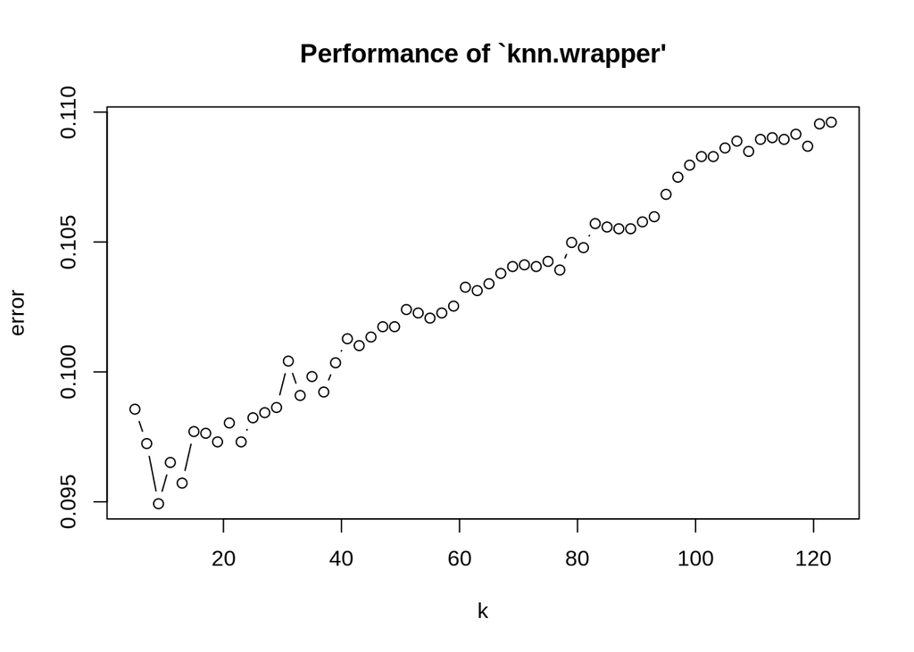

```r
#Plot the error rate
plot(knn_cross)
```

## 4.2 Resampling using bootstraping

```r
tic()
knn_boot <- tune.knn(x = x_train, y = y_train, k = k_values, tunecontrol=tune.control(sampling = "boot") )
#Summarize the resampling results set
summary(knn_boot)
```

```
##
## Parameter tuning of 'knn.wrapper':
##
## - sampling method: bootstrapping
##
## - best parameters:
##   k
##  33
##
## - best performance: 0.1024841
##
## - Detailed performance results:
##      k     error  dispersion
## 1    5 0.1143007 0.003764308
## 2    7 0.1091364 0.003898030
```

[output cut: 58 more lines]

```r
toc()
```

```
## 1284.721 sec elapsed
```

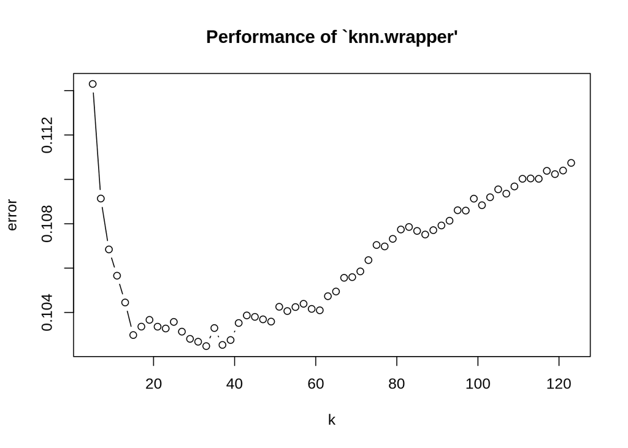

```r
#Plot the error rate
plot(knn_boot)
```

## 4.3 Resampling fixed set

```r
tic()
knn_fix <- tune.knn(x = x_train, y = y_train, k = k_values,tunecontrol=tune.control(sampling = "fix") , fix=10)
#Summarize the resampling results set
summary(knn_fix)
```

```
##
## Parameter tuning of 'knn.wrapper':
##
## - sampling method: fixed training/validation set
##
## - best parameters:
##   k
##  11
##
## - best performance: 0.1039889
##
## - Detailed performance results:
##      k     error dispersion
## 1    5 0.1099424         NA
## 2    7 0.1067672         NA
```

[output cut: 58 more lines]

```r
toc()
```

```
## 75.782 sec elapsed
```

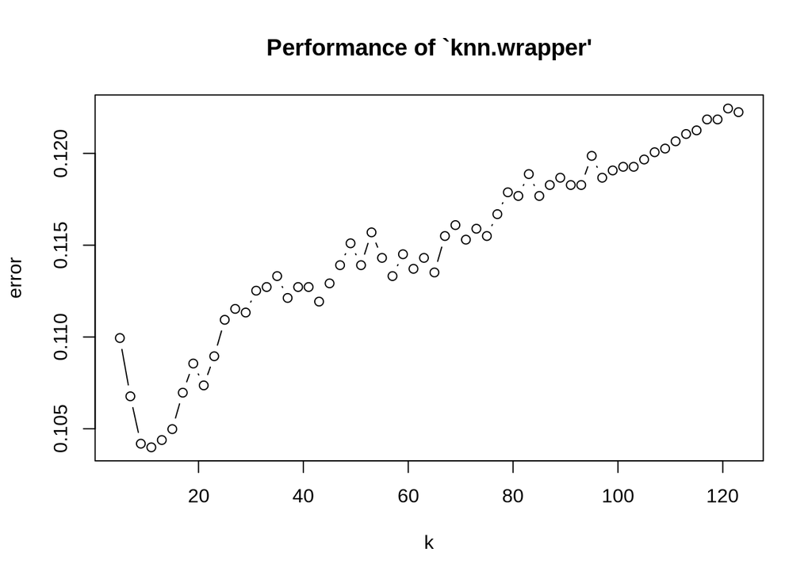

```r
#Plot the error rate
plot(knn_fix)
```

## 4.4 Checking best K neighbor

En este apartado vamos a buscar el mejor k-neighbor dentro de los seleccionados. Tras este paso será el K = 13 el que da un mayor accuracy.

```r
k_best <- c(7, 13, 19)
for (k in k_best) {
  knn_pred <- knn(x_train, x_val, y_train, k, prob=TRUE)
  knn_prob <- attr(knn_pred, "prob")
  cm <- table(knn_pred, y_val)
  accuracy <- sum(diag(cm))/sum(cm)
  output = sprintf("The validation accuracy of the %s-KNN model is: %s", k, accuracy)
  print(output)
  roc_knn <- rocit(knn_prob, knn_pred)
  if (k == k_best[1]) {
    plot(roc_knn, col = 3, legacy.axes = TRUE)
  } else if (k == k_best[2]) {
    lines(roc_knn$TPR ~ roc_knn$FPR, col = 2, lwd = 3)
  } else {
    lines(roc_knn$TPR ~ roc_knn$FPR, col = 4)
  }
}
```

```
## [1] "The validation accuracy of the 7-KNN model is: 0.892361111111111"
```

```
## [1] "The validation accuracy of the 13-KNN model is: 0.897453703703704"
## [1] "The validation accuracy of the 19-KNN model is: 0.894907407407407"
```

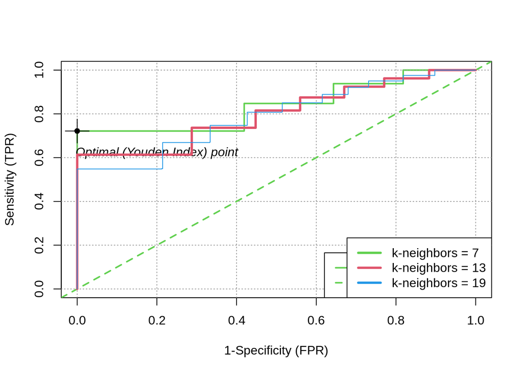

```r
legend("bottomright", col = c(3 ,2, 4),
       c('k-neighbors = 7', 'k-neighbors = 13', 'k-neighbors = 19'), lwd = 3)
```

## 4.5 The best k-neighbor

```r
k = 13
knn_pred <- knn(x_train, x_val, y_train, k, prob=TRUE)
knn_prob <- attr(knn_pred, "prob")
cm <- table(knn_pred, y_val)
accuracy <- sum(diag(cm))/sum(cm)
output = sprintf("The validation accuracy of the %s-KNN model is: %s", k, accuracy)
print(output)
```

```
## [1] "The validation accuracy of the 13-KNN model is: 0.897453703703704"
```

```r
roc_knn <- rocit(knn_prob, knn_pred)
summary(roc_knn)
```

```
##
##  Empirical ROC curve
##  Number of postive responses :  3353
##  Number of negative responses :  967
##  Area under curve :  0.800310947210836
```

```r
# Confidence interval of AUC
ciAUC(roc_knn, level = 0.95)
```

```
##
##    estimated AUC : 0.800310947210836
##    AUC estimation method : empirical
##
##    CI of AUC
##    confidence level = 95%
##    lower = 0.786631010952517     upper = 0.813990883469154
```

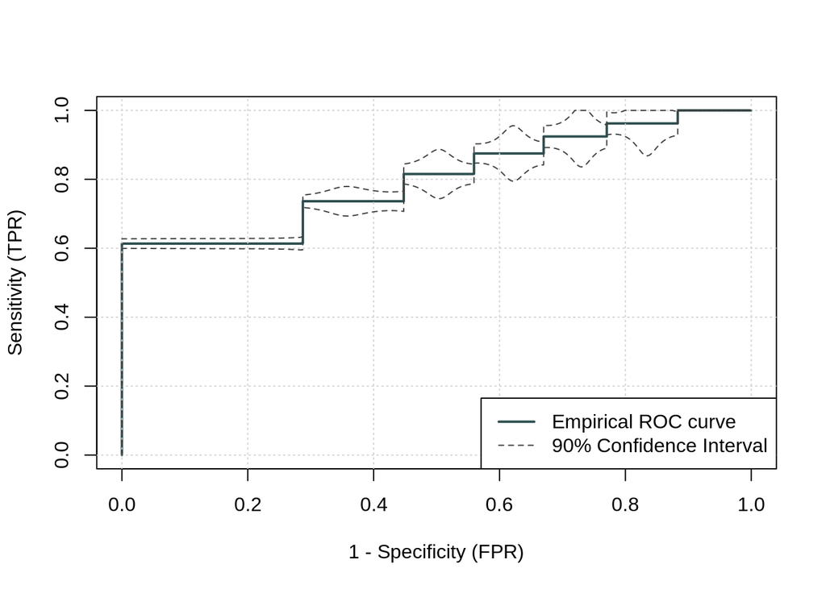

```r
# Confidence interval of ROC curve
plot(ciROC(roc_knn, level = 0.9))
```